# Lab 4 Data Science

Ashlan Simpson

3/3/2021

```r
dat <- readxl::read_xls('/Users/Ashlan/Downloads/GSS.xls')
```

```r
library(ggplot2)
library(dplyr)
```

1. Find the average years of education for the respondents with each marital status. Arrange your output in a meaningful order and print. Describe any patterns you find. No Answer is the highest by two years which is pretty significant. Those who are widowed are the lowest which makes sense since they are likely to be the oldest and therefore from a time where most people didn’t have as much education. Aside from that there isn’t a great pattern.

```r
dat1 <- dat %>% mutate(Educ = as.numeric(`Highest year of school completed`))
dat2 <- dat1 %>% mutate(x = factor(`Marital status`, c("Never married", "Married", "Separated", "Divorced", "Widowed", "No answer") ))
dat2 %>%
  group_by(`x`) %>%
  summarise(newName = mean(`Educ`, na.rm = TRUE))
```

```
## # A tibble: 7 x 2
##   x             newName
##   <fct>           <dbl>
## 1 Never married    13.4
## 2 Married          13.0
## 3 Separated        11.9
## 4 Divorced         13.1
## 5 Widowed          11.2
## 6 No answer        15.5
## 7 <NA>            NaN
```

2. Create a single data frame containing records for the better educated respondents with each marital status. A “better educated” respondent is someone who has strictly more years of education than the average among those with the same marital status. Print the structure of the data frame.

```r
dat3 <- dat2 %>%
  group_by(`x`) %>%
  filter(`Educ` > mean(`Educ`, na.rm = TRUE))
str(dat3)
```

```
## tibble [30,714 x 10] (S3: grouped_df/tbl_df/tbl/data.frame)
##  $ Gss year for this respondent    : num [1:30714] 1972 1972 1972 1972 1972 ...
##  $ Respondent id number            : num [1:30714] 1 4 6 8 11 16 17 19 20 23 ...
##  $ Marital status                  : chr [1:30714] "Never married" "Married" "Never married" "Never married" ...
##  $ Highest year of school completed: chr [1:30714] "16" "17" "14" "16" ...
##  $ Respondents sex                 : chr [1:30714] "Female" "Female" "Male" "Male" ...
##  $ Political party affiliation     : chr [1:30714] "Ind,near dem" "Not str democrat" "Ind,near dem" "Ind,near dem" ...
##  $ General happiness               : chr [1:30714] "Not too happy" "Not too happy" "Pretty happy" "Not too happy" ...
##  $ Ballot used for interview       : chr [1:30714] "Not applicable" "Not applicable" "Not applicable" "Not applicable" ...
##  $ Educ                            : num [1:30714] 16 17 14 16 13 14 14 17 14 13 ...
##  $ x                               : Factor w/ 6 levels "Never married",..: 1 2 1 1 2 2 2 2 1 2 ...
##  - attr(*, "groups")= tibble [6 x 2] (S3: tbl_df/tbl/data.frame)
##   ..$ x    : Factor w/ 6 levels "Never married",..: 1 2 3 4 5 6
##   ..$ .rows: list<int> [1:6]
##   .. ..$ : int [1:6250] 1 3 4 9 13 17 21 22 25 28 ...
##   .. ..$ : int [1:16040] 2 5 6 7 8 10 11 12 14 15 ...
##   .. ..$ : int [1:1458] 43 44 51 89 107 108 128 141 156 221 ...
##   .. ..$ : int [1:3414] 23 41 56 77 166 208 250 304 334 378 ...
##   .. ..$ : int [1:3538] 47 76 81 87 99 103 113 115 122 125 ...
##   .. ..$ : int [1:14] 9288 10465 11676 13143 22339 22935 22950 22986 23943 26304 ...
##   .. ..@ ptype: int(0)
##   ..- attr(*, ".drop")= logi TRUE
```

3. How is the happiness of a respondent related to his/her marriage status? Define that a person is happy if the response to question is “Very happy” or “Pretty happy”. The graphs feel fairly similar although married people seem the happiest between pretty happy and very happy. In fact their very happy is close to 40%. Separated is also by far the group with the least happy people.

```r
df <- filter(dat2, is.na(`General happiness`) == F )
df1 <- filter(df, is.na(`Marital status`) == F )
a = df1 %>% group_by(`Marital status`, `General happiness`) %>%
  summarize(`General happiness.n` = n()) %>%
  mutate(`General happiness.per` = `General happiness.n`/ sum(`General happiness.n`))
```

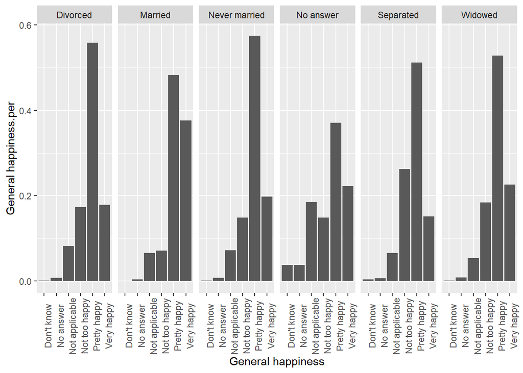

```r
a %>%
  ggplot(aes(x = `General happiness`, y= `General happiness.per`)) +
  geom_bar(stat = 'identity') + theme(axis.text.x = element_text(angle = 90)) + facet_grid(~`Marital status`)
```

```r
b = df1 %>% group_by(`Marital status`, `Political party affiliation`) %>%
  filter(`General happiness` == "Pretty happy" | `General happiness` == "Very happy") %>%
  summarize(`General happiness.n` = n()) %>%
  mutate(`General happiness.per2` = `General happiness.n`/ sum(`General happiness.n`))
```

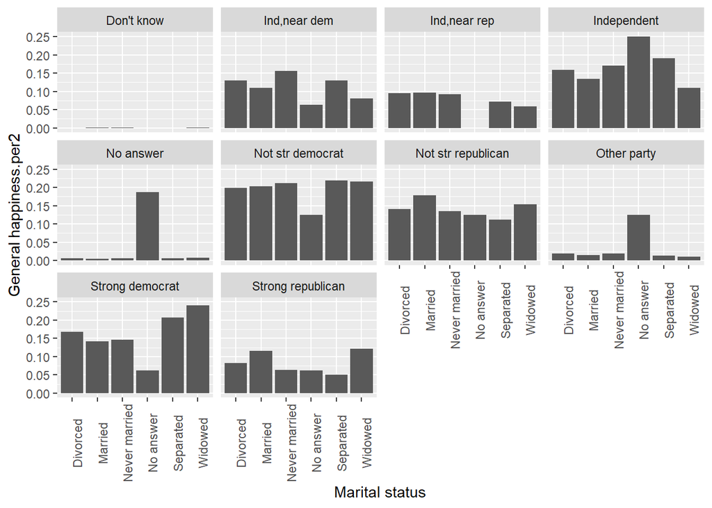

```r
b %>%
  ggplot(aes(x = `Marital status`, y = `General happiness.per2`)) +
  geom_bar(stat = 'identity') + theme(axis.text.x = element_text(angle = 90)) +
  facet_wrap(~`Political party affiliation`)
```

5) How is marital status related to the education of a respondent? What are possible reasons accounting for the patterns you see? The graphs seem to be about the same shape except MArried might tend higher. I think the people who are likely to be married may have traits like hard working that are make for a better student and would therefore be more like to countinue education.

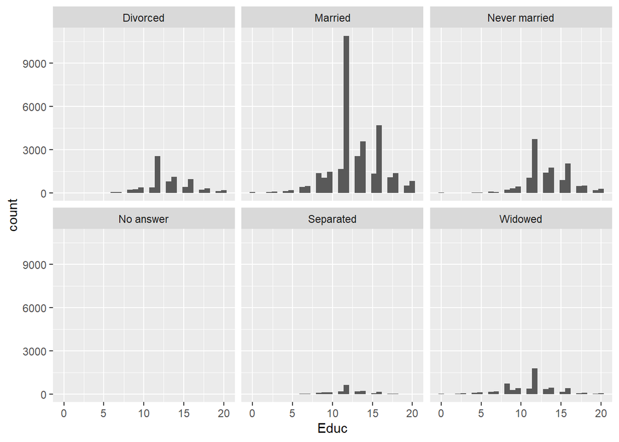

```r
df1 %>%
  ggplot(aes(x=Educ)) + geom_histogram() + facet_wrap(~`Marital status`)
```

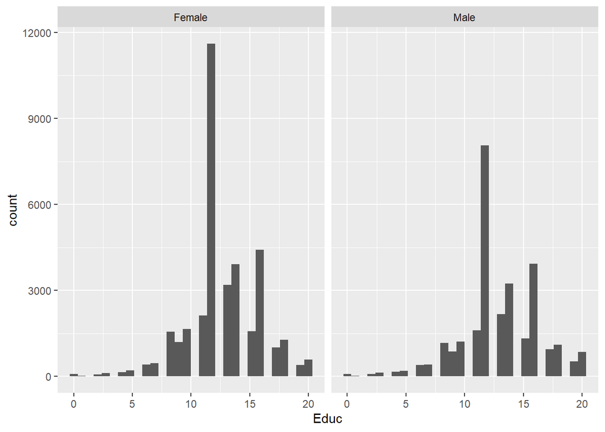

```r
df1 %>%
  ggplot(aes(x=Educ)) + geom_histogram() + facet_wrap(~`Respondents sex`)
```

```r
c = df1 %>% group_by(`Respondents sex`, `General happiness`) %>%
  summarize(`General happiness.n` = n()) %>%
  mutate(`General happiness.per3` = `General happiness.n`/ sum(`General happiness.n`))
```

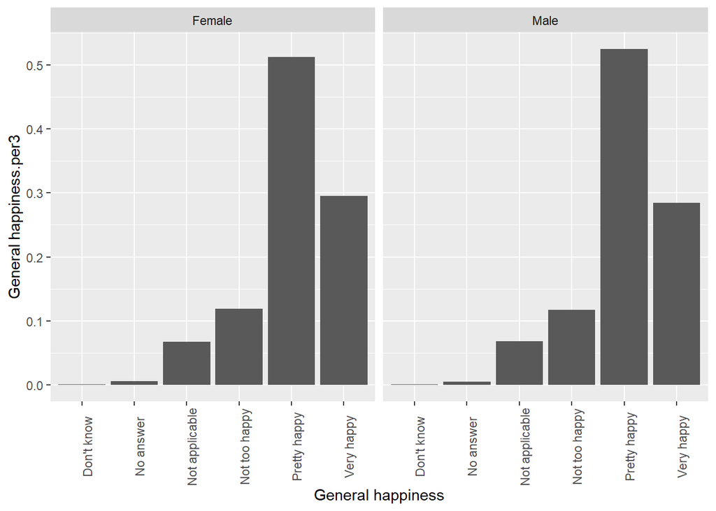

```r
c %>%
  ggplot(aes(x = `General happiness`, y= `General happiness.per3`)) +
  geom_bar(stat = 'identity') + theme(axis.text.x = element_text(angle = 90)) +
  facet_grid(~`Respondents sex`)
```